# Part II - An overview of the bike-sharing system in San Francisco Bay area

## by Mobuolafoluwa Onayade

## Investigation Overview

In this investigation, I wanted to explore the factors that affect the duration of bike rides. The main focus was on age and gender of the rider as well time of day and time of week of the bike ride

## Dataset Overview

The dataset consisted of duration and attributes of 183,412 bike rides made in a bike-sharing system covering the greater San Francisco Bay area . The attributes included start and end stations, year of birth and gender of riders, as well as additional measurements such as user type and Bike share for all trip status. New variables such as time of day, weekday and age were created to better explore relationships

## Distribution of Duration of Bike Rides

Duration of bike rides in the dataset take on a very large range of values, from about 1 minute at the lowest, to about 1424 at the highest. Plotted with a limit of 60 minutes the distribution is right skewed. There is a steady decline in the number of bike rides taken for more than 10 minutes

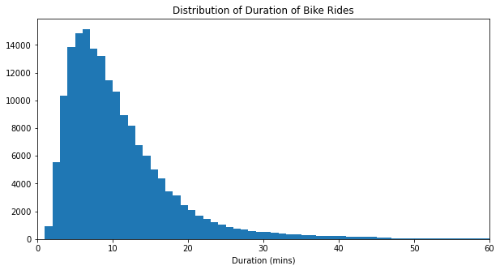

## Duration of bike rides vs Time of day

Plotting the duration of bike rides and time of the day of the ride shows that there is a relationship between the time of the day a trip is taken and how long it lasts for. Bike rides taken during the day are most longer than those taken at night.

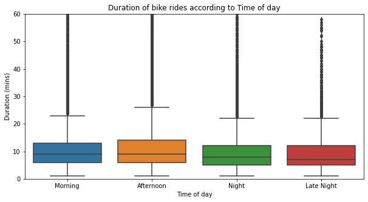

## Bike ride duration (in mins) by age and gender

Exploring the interactions between bike ride duration and age and gender. Average bike ride increases as age increases showing that older people ride longer. However, males ride for a shorter time showing that an older woman rides longer than the man

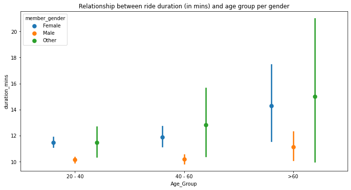